# Chapter 3 Investigate Dataset

## Objective

Many factors go into making European Soccer one of the most thrilling sports to watch. This analysis will dive into some of the analytics behind "The Beautiful Game" and what makes some teams and players more successful than others.

## Dataset

The dataset used in this analysis will be the European Soccer Database that is hosted on [Kaggle](https://www.kaggle.com/hugomathien/soccer/data). This datasets contains data on over 25,000 matches and 10,000 players, ranging from the 2008 season to the 2016 season. The player and team attributes used in this dataset were pulled from the EA Sports' FIFA video game series.

The data is stored in a sqlite database. Since this analysis will be performed in Python, each table will be extracted from the sqlite database and into a corresponding CSV file. This was done using the [DB Browser for SQLite application](http://sqlitebrowser.org/).

## Questions

- Which team(s) improved the most from 2008 to 2016?
- What correlates to a higher winning percentage: a better offense or a better defense?

## Import Data

```python
# Import the tables needed for the analysis
import pandas as pd
import numpy as np
import matplotlib as mpl
import matplotlib.pyplot as plt
from scipy import stats

df_country = pd.read_csv('dataset/Country.csv') #import country information
df_league = pd.read_csv('dataset/League.csv') #import league information
df_match = pd.read_csv('dataset/Match.csv') #import match information
df_team = pd.read_csv('dataset/Team.csv') #import basic team information
```

## Data wrangling

To begin the analysis, the data must be transformed into a manner that can be analyzed and visualized. The 'match' dataframe will first be filtered to only select the relevant columns.

```python
df_match = df_match.iloc[:,0:11]
```

Next, the 'season' column of the match dataframe will need to be altered. It is currently formatted with two dates, denoting both the starting and ending year for the season. For this data analysis, only the starting year will be leverages. The ending year will be removed from the column so the season can be properly used for time analysis.

```python
df_match['season'] = df_match['season'].str[:4]
```

The winner and loser for each match will also need to be denoted, which can be determined by comparing the home team goals to the away team goals. Two new columns in the 'match' dataframe will be created using the 'where' function from the numpy package.

```python
# set winner for each match based off which team had more goals
df_match['winning_team'] = np.where(
                        df_match['home_team_goal'] > df_match['away_team_goal'],
                        df_match['home_team_api_id'],
                        np.where(
                            df_match['home_team_goal'] < df_match['away_team_goal'],
                            df_match['away_team_api_id'],
                            'draw')
                     )
# set loser for each match based off which team had less goals
df_match['losing_team'] = np.where(
                        df_match['home_team_goal'] < df_match['away_team_goal'],
                        df_match['home_team_api_id'],
                        np.where(
                            df_match['home_team_goal'] > df_match['away_team_goal'],
                            df_match['away_team_api_id'],
                            'draw')
                     )
```

With the winners and losers set for each match, the winning percentage for each team by season is one step closer. To calculate teh winning percentage for each team, the total games won will need to be calculated and then divided by the total games played. More manipulation will need to be done to the 'match' dataframe before the total games won or total games can be calculated. Since matches incorporate two teams, home and away team, the dataframe only shows half of the rows needed for each team.

To get the total games played and won by each team, the data frame will be split into two separate dataframes: one where only the home team is selected, anda the other for only the away team. The team_id and goal columns will be renamed appropriately as well to ensure consistent naming between dataframes

```python
# split home and away team information into separate dataframes and rename columns appropriately
df_home_teams = df_match[['league_id', 'id', 'season', 'home_team_api_id', 'home_team_goal', 'away_team_goal']]
df_away_teams = df_match[['league_id', 'id', 'season', 'away_team_api_id', 'away_team_goal', 'home_team_goal']]
df_home_teams = df_home_teams.rename(columns={'home_team_api_id':'team_id', 'home_team_goal':'goals_for', 'away_team_goal':'goals_against'})
df_away_teams = df_away_teams.rename(columns={'away_team_api_id':'team_id', 'away_team_goal':'goals_for', 'home_team_goal':'goals_against'})
```

Next, the separated data frames will need to be appended onto one another to get all the teams into one dataframe. This frame will then be grouped by league, team, and season to get the total matches played by season. A new column will also be created that is called 'goal ratio.' This column will represent total goals scored by the team divided by the total goals scored against the team.

```python
# append team files to get the total matches per team by season
df_total_teams = df_home_teams.append(df_away_teams)
df_total_teams.drop_duplicates(inplace=True)
df_total_teams = df_total_teams.groupby(['league_id', 'team_id', 'season'], as_index=False).agg({'id':'count', 'goals_for':'sum', 'goals_against':'sum'})
df_total_teams = df_total_teams.rename(columns={'id':'total_games', 'goals_for':'total_goals_for', 'goals_against':'total_goals_against'})
df_total_teams['goal_ratio'] = ((df_total_teams['total_goals_for']/df_total_teams['total_goals_against'])).round(2)
df_total_teams['team_id'] = df_total_teams['team_id'].astype(str)
```

Before the win percentage can be calculated, the total wins per season will need to be calculated. To get the total wins, the df_match dataframe will be grouped by the winning team and by season. This will give the total wins per season for each team.

```python
# set wins per season for each team in separate files
df_team_wins = df_match[['league_id', 'id', 'winning_team','season']].groupby(['winning_team','season'], as_index=False).agg({'id':'count'})
df_team_wins = df_team_wins.rename(columns={'id':'total_wins', 'winning_team':'team_id'})
```

With the total games for each team aggregated, and the total wins for each team aggregated, the dataframes can be merged. Once the merged, the winning percentage can be calculated for each team by season.

Also, in the average goals scored for and against each team by season will be calculated in this step.

```python
# merge total games and total win dataframes and then calculate win percentage
df_team_mrg = pd.merge(df_total_teams, df_team_wins, on=['team_id','season'], how='inner')
df_team_mrg['win_pct'] = ((df_team_mrg['total_wins']/df_team_mrg['total_games']) * 100).round(2)
df_team_mrg['avg_goals_for'] = df_team_mrg['total_goals_for']/df_team_mrg['total_games']
df_team_mrg['avg_goals_against'] = df_team_mrg['total_goals_against']/df_team_mrg['total_games']
df_team_mrg = df_team_mrg[['league_id', 'team_id','season','total_games','total_wins', 'win_pct', 'total_goals_for', 'total_goals_against','avg_goals_for','avg_goals_against', 'goal_ratio']]
```

The currently merged dataframe is using the team_id field. This isn't a very informative field, so the merged dataframe will then be combined with the team dataframe that was originally imported. This will provide the new dataframe with the proper team short name and team long name.

```python
# convert df_team id to string for merging and filter to only necessary columns
df_team['team_api_id'] = df_team['team_api_id'].astype(str)
df_team = df_team[['team_api_id','team_fifa_api_id','team_long_name', 'team_short_name']]

# merge team df with wrangle "merged" team df to get team info
df_team_mrg = pd.merge(df_team, df_team_mrg, left_on = 'team_api_id', right_on = 'team_id', how = 'inner')
df_team_mrg = df_team_mrg[['league_id', 'team_id', 'team_short_name', 'team_long_name', 'season', 'total_games', 'total_wins', 'win_pct', 'total_goals_for', 'total_goals_against','avg_goals_for','avg_goals_against', 'goal_ratio']]
df_team_mrg['team_id'] = df_team_mrg['team_id'].astype(int)
df_team_mrg['season'] = df_team_mrg['season'].astype(int)
df_team_mrg = df_team_mrg.sort_values(by=['league_id', 'team_id', 'season'],ascending=True).reset_index(drop=True)
```

Lastly, the first question posed in this analysis was which team(s) improved the most between the 2008 and 2015 seasons. This will require just a bit more wrangling to accomplish.

First since we are only looking for teams that improved the most between all seven years, we will want to exclude any teams that didn't play in all of these seasons. This will require getting the maximum and minimum season for each team and comparing each team to ensure all seven seasons are included. Any teams that don't meet this criteria will be filtered out and the remaining teams will be placed in a new dataframe called df_team_fltrd.

A new column will also be created called "win_dif" that'll represent the change in wins between the 2008 and 2015 seasons.

All of this wrangling can be seen in the step below.

```python
# group bys for seasons
df_team_max = df_team_mrg.groupby(['league_id', 'team_id'], as_index=False).agg({'season':'max'})
df_team_min = df_team_mrg.groupby(['league_id', 'team_id'], as_index=False).agg({'season':'min'})

# Max year
df_team_max_mrg = pd.merge(df_team_mrg, df_team_max, on = ['league_id', 'team_id', 'season'], how = 'inner')
df_team_max_mrg = df_team_max_mrg[['league_id', 'team_id', 'season', 'total_wins']]
df_team_max_mrg = df_team_max_mrg.rename(columns={'season':'max_season', 'total_wins':'max_season_wins'})

# Min year
df_team_min_mrg = pd.merge(df_team_mrg, df_team_min, on = ['league_id', 'team_id', 'season'], how = 'inner')
df_team_min_mrg = df_team_min_mrg[['league_id', 'team_id', 'season', 'total_wins']]
df_team_min_mrg = df_team_min_mrg.rename(columns={'season':'min_season', 'total_wins':'min_season_wins'})

# Merge
df_team_minmax_mrg = pd.merge(df_team_max_mrg, df_team_min_mrg, on=['league_id', 'team_id'], how = 'inner')
df_team_minmax_mrg['max_season'] = df_team_minmax_mrg['max_season'].astype(int)
df_team_minmax_mrg['min_season'] = df_team_minmax_mrg['min_season'].astype(int)

# Find number of seasons for a full record set
df_team_minmax_mrg['win_dif'] = df_team_minmax_mrg['max_season_wins'] - df_team_minmax_mrg['min_season_wins']
df_team_minmax_fltrd = df_team_minmax_mrg.query('(max_season-min_season) == max_season.max()-min_season.min()')

# Final team dataframe for plotting
df_team_fltrd = pd.merge(df_team_mrg, df_team_minmax_fltrd, on = ['league_id', 'team_id'], how='inner')
df_team_fltrd['season'] = df_team_fltrd['season'].astype(int)
```

With the data wrangled and transformed into a more useable fashion, the data visualization steps can begin.

## Data Analysis and Visualization

With the data wrangled, we can been visualizing and analyzing the data. Since our first question was which team improved the most over the course of the seven seasons, we will begin by plotting each teams win percentage for each season. This will give us a visual of how each team improved over time.

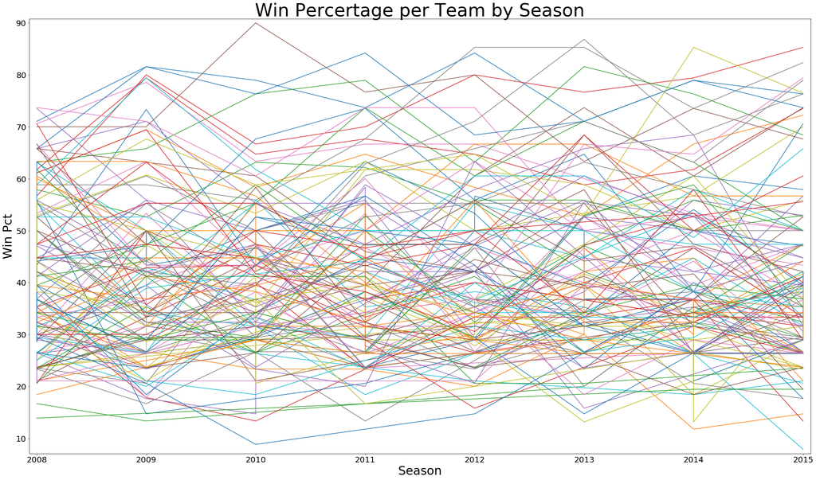

```python
# Plot
fig, ax = plt.subplots(figsize=(35,20)) # increase the figure size for the plot
ax.margins(0.01)
for name, group in df_team_fltrd.groupby('team_short_name'):
    ax.plot(group.season.sort_values(ascending=True), group.win_pct, label=name)
ax.set_xlabel('Season',fontsize = 30)
ax.set_ylabel('Win Pct',fontsize = 30)
ax.tick_params(axis = 'both', which = 'major', labelsize = 20)
plt.title('Win Percertage per Team by Season',fontdict={'fontsize':45})

plt.show()
```

This is clearly not a good visualization. With nearly 300 teams across all the leagues, there ends up being too much data on one plot. So much data, that we couldn't even fit a legend onto the graph to see which line represents which team.

To remedy this issue, we will filter the data one more time, but this time only select the teams with the top 10 largest win differentials. This filtered dataframe will then be plotted and should provide an easier view for tracking these teams over time.

To get this dataframe, we will need to sort the data by 'win_dif', which is our win differential field. Then we will take only the top 10 records from this list and merge with our existing df_team_mrg dataframe, which is our rolled up match information dataframe. This will give us all the aggregated data we need for our top 10 teams and allow us to plot.

```python
# sort teams by winning differential
df_team_fltrd = df_team_minmax_fltrd.sort_values(by=['win_dif','league_id', 'team_id'],ascending=False).reset_index(drop=True)

# select only top 10 teams as well as merge with team data
df_team_fltrd = pd.merge(df_team_mrg, df_team_fltrd.head(10), on = ['league_id', 'team_id'], how='inner')
```

Before we plot the data, let's see which teams we expect to rise the most over the course of the seasons. This will be done by grouping the df_team_fltrd dataframe by team, and selecting the maximum win differential. Since the win differential field is a constant for each team, selecting the max will not affect the results. These records will also be sorted by win differential to make it even clearer.

```python
df_team_fltrd.groupby('team_long_name', as_index = False).agg({'win_dif':'max'}).sort_values(by=['win_dif'],ascending=False).reset_index(drop=True)
```

|  | team_long_name | win_dif |
| --- | --- | --- |
| 0 | Napoli | 13 |
| 1 | SL Benfica | 12 |
| 2 | Paris Saint-Germain | 11 |
| 3 | Borussia Dortmund | 9 |
| 4 | Borussia Mönchengladbach | 9 |
| 5 | Aberdeen | 8 |
| 6 | Atlético Madrid | 8 |
| 7 | FC Bayern Munich | 8 |
| 8 | Juventus | 8 |
| 9 | Piast Gliwice | 8 |

As the above output shows, we expect to see Napoli rise the most with a win differential of 13 games across the seven seasons. Napoli will be followed by SL Benfica as 12, and then Paris Saint-Germain as 11.

Now let's plot this data, so we can see how each team rose and fell over the course of the seasons. This plot will be slightly different than the plot from above. Instead of plotting win percentage by season, we will plot total wins by season. This will allow us to better compare against the dataframe we outputted above.

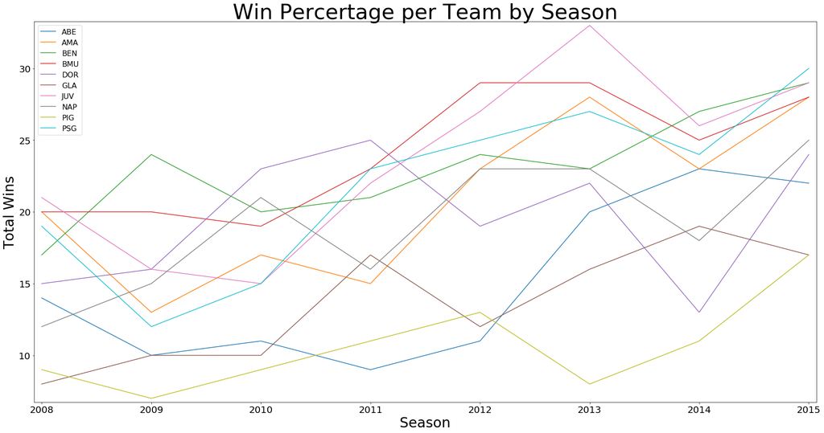

```python
# Plot
fig, ax = plt.subplots(figsize=(30,15))
ax.margins(0.01)
for name, group in df_team_fltrd.groupby('team_short_name'):
    ax.plot(group.season.sort_values(ascending=True), group.total_wins, label=name)
ax.legend()
ax.set_xlabel('Season',fontsize = 30)
ax.set_ylabel('Total Wins',fontsize = 30)
ax.tick_params(axis = 'both', which = 'major', labelsize = 20)
plt.title('Win Percertage per Team by Season',fontdict={'fontsize':45})
plt.legend(loc=2, prop={'size': 16})
plt.show()
```

If we follow Napoli's line, we can see that their Total Wins goes from what looks like 12 all the way to 25. This confirms the number we saw in our initial dataframe of a 13 game differential. If we follow each line as well we can see that Napoli again had the largest win differential between 2008 and 2015.

Now to check how goals correlate to winning percentage. This will be done by creating a scatterplot of goal ratio, which from our data wrangling is total goals for divided by total goals against, and plotting against the win percentage. It's worth noting that this plot will utilize the df_team_mrg dataframe, and not the df_team_fltrd dataframe from the above plot. This is because the df_team_mrg dataframe contains data for all teams, regardless of how many seasons were played. This is done to bump up our data size and give us more confidence in our correlation.

I expect we will see a very strong correlation where a higher goal ratio yields a higher win percentage, because if you are scoring more often than your opponent, then you are liking winning more games.

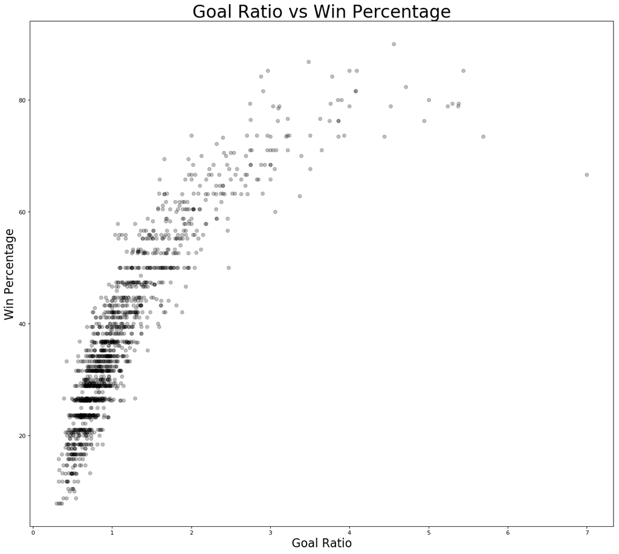

```python
# Plot
plt.figure(figsize=(18, 16), dpi= 80, facecolor='w', edgecolor='k')

goal_ratio = df_team_mrg['goal_ratio']
win_pct = df_team_mrg['win_pct']

plt.scatter(goal_ratio, win_pct, c="black", alpha=.25)
plt.xlabel("Goal Ratio", fontsize = 20)
plt.ylabel("Win Percentage", fontsize = 20)
ax.tick_params(axis = 'both', which = 'major', labelsize = 20)
plt.title('Goal Ratio vs Win Percentage',fontdict={'fontsize':30})
plt.show()
```

As we expected, there is a very strong positive correlation between Goal Ratio and Win Percentage. As a team has a higher goal ratio, they also tend to win more games.

However, this is a somewhat obvious statistic. A more meaningful correlation would be to see if a team scoring more goals correlates to a higher win percentage than a team preventing more goals scored. In other words, would you rather play better offense or defense.

This correlation will be generated similarly to above, however, instead of plotting win percentage again goal ratio, win percentage will be plotted against both avg_goals_for and avg_goals_against. The average goals for will be represented by black dots, while teh avg goals against will be represented by red.

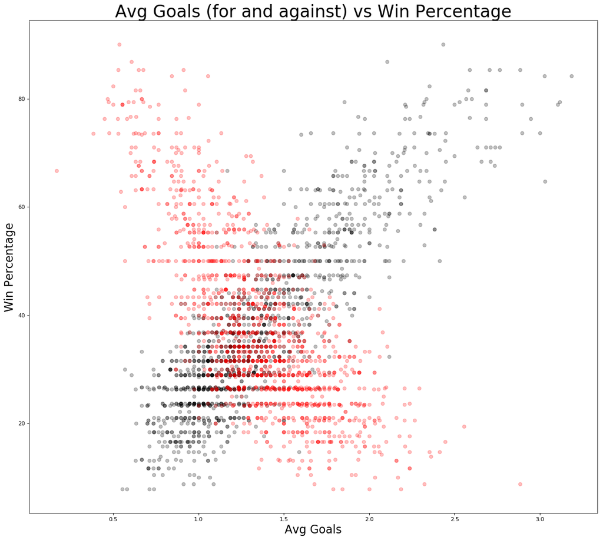

```python
plt.figure(figsize=(18, 16), dpi= 80, facecolor='w', edgecolor='k')

plt.scatter(df_team_mrg['avg_goals_for'], df_team_mrg['win_pct'], c="black", alpha=.25)
plt.scatter(df_team_mrg['avg_goals_against'], df_team_mrg['win_pct'], c="red", alpha=.25)
plt.xlabel("Avg Goals", fontsize = 20)
plt.ylabel("Win Percentage", fontsize = 20)
ax.tick_params(axis = 'both', which = 'major', labelsize = 20)
plt.title('Avg Goals (for and against) vs Win Percentage',fontdict={'fontsize':30})
plt.show()
```

This visualization is a bit harder to interpret and determine which of the two variables correlates to a higher win percentage. The average goals scored for each team has a very strong positive correlation with win percentage, so it seems that as a team scores more, it will win more. However, average goals scored against each team has a very strong negative correlation. So the less goals you allow a team to score, the more games you can expect to win.

To check determine which of these has a stronger correlation, we will need to calculate the p-value for each dataset. The p-value will output a number between -1 and 1 that will represent how strong of a correlation we are getting. The closer to +1 equals a stronger postive correlation and the closer to -1 equals a stronger negative correlation.

We will expect our p-value for the avg_goals_for vs win_pct to be a strong positive, and our p-value for avg_goals_against vs win_pct to be a strong negative. Whichever correlation is closer to their corresponding "1" value will be deemed the stronger correlation.

However, before we can calculate our p-values, we need to make all of our variables contain a normal distribution. This will be done by plotting a histogram for each of the three variables. If the variables are normally distributed, we'd expect to see one large bump in each histogram.

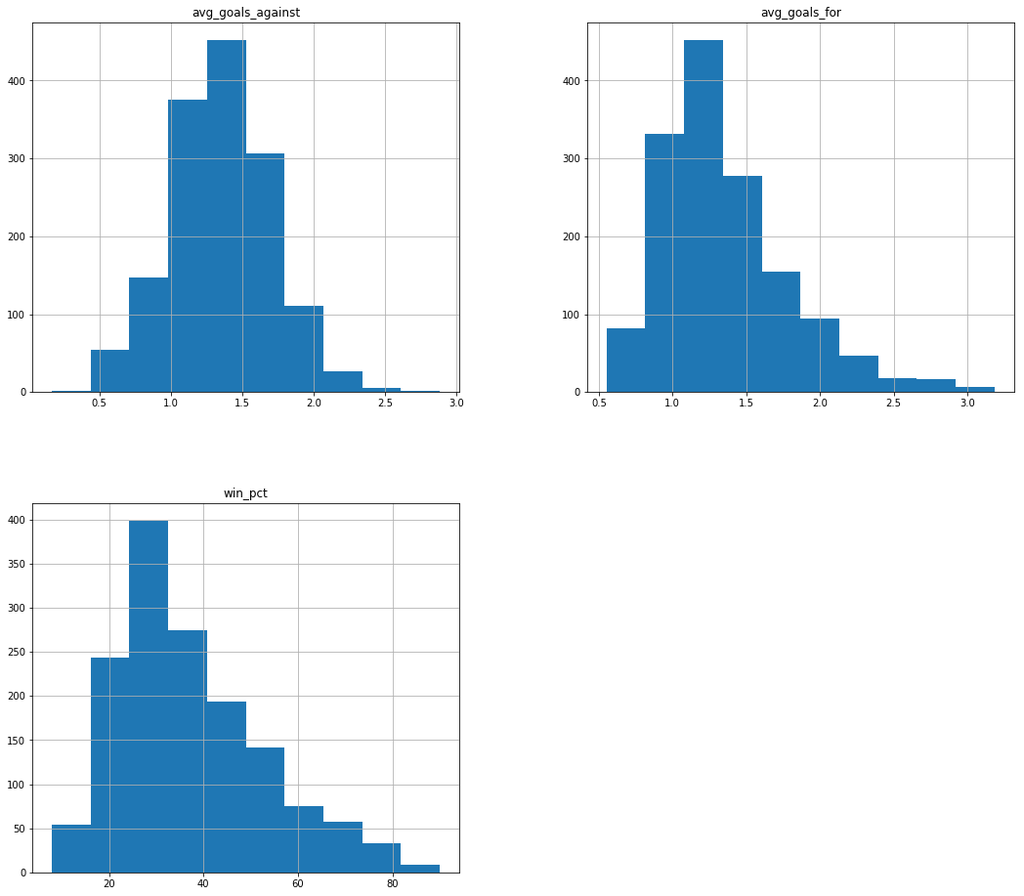

```python
_ = df_team_mrg[['win_pct', 'avg_goals_for', 'avg_goals_against']].hist(figsize=(18, 16))
# the _ =  is used to suppress unwanted dimension output by the histogram
```

As can be seen, each of the variables has a good normal distribution. The avg_goals_for and win_pct are both mildly right-skewed, which shows they both have a few outlier datapoints.

Now that we've confirmed all the variables needed to calculated the p-value are normally distributed, we can begin generating the p-value. This will be done by using a package called stats in the scipy module, which we've imported, but haven't used up to this point.

```python
pAvgGoalsFor = stats.pearsonr(df_team_mrg['avg_goals_for'], df_team_mrg['win_pct'])[0]
pAvgGoalsAgainst = stats.pearsonr(df_team_mrg['avg_goals_against'], df_team_mrg['win_pct'])[0]

print("Average Goals For Correlation: " + str(pAvgGoalsFor))
print("Average Goals Against Correlation: " + str(pAvgGoalsAgainst))
```

```
Average Goals For Correlation: 0.8603339752209761
Average Goals Against Correlation: -0.7291276372033627
```

We can be seen, Goals For has a stronger correlation towards Win Pct than Goals Against. This is interpreted because Avg Goals For has a p-value of .86, which is very close to 1. Avg Goals Against does have a strong negative correlation with -0.73, however, it's not as strong as the correlation seen by Avg Goals For.

## Conclusion

In conclusion, we were able to see that between 2008 and 2015, Napoli made the most improvement to their winning percentage. However, this result was limited due to excluding any teams that we didn't play for all seven seasons. There may have been teams that had a higher win differential, but we were not able to see due to excluding them from the analysis.

We were also able to see that scoring more goals leads to more wins than preventing goals. So if you had to choose between playing good offense or good defense, it's better to focus your efforts on offense. However, this will only apply to European Soccer.

Since this dataset is partially generated from data within Fifa, it'd be interesting in the future to see how strongly each variable in the overall player rating correlates to a higher player score.

It would also be interesting to see if a team's average height leads to different winning percentages. However, this cannot be done until it's possible to link a player to each team.